# 03-ProbabilityDistributionsDiscrete

## **Discrete Distributions**

[figure not shown]

### Binomial Distribution

The binomial distribution is the discrete probability distribution that gives only two possible results in an experiment, either Success or Failure

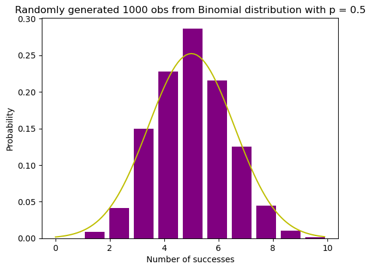

```python
import numpy as np
#Random Generations of 1000 independent Binomial samples
# (fair coin tosses 10 times in each experiment) 1000 times
n = 10
p = 0.5
N = 1000
X = np.random.binomial(n,p,N)

#Plotting Binomial distribution and adding Normal distribution line
import matplotlib.pyplot as plt
from scipy.stats import norm

# population mean and sigma
mu = n*p
sigma = np.sqrt(n*p*(1-p))
x_values = np.arange(0,10,0.1)


# histogram of Binomial distribution
counts, bins, ignored = plt.hist(X, 10, density = True, rwidth = 0.8, color = 'purple')

# Plot of Normal distribution
plt.plot(x_values, norm.pdf(x_values, mu,sigma), color = 'y', linewidth = 1.5)
plt.title("Randomly generated 1000 obs from Binomial distribution with p = 0.5")
plt.xlabel("Number of successes")
plt.ylabel("Probability")
plt.show()
```

```python
import numpy as np
two_rej = np.random.binomial(20, 0.12, 10)
```

```python
two_rej
```

```
array([1, 3, 1, 1, 2, 1, 3, 4, 2, 1])
```

```python
import matplotlib.pyplot as plt
import seaborn as sns
sns.set_theme(style="whitegrid")
```

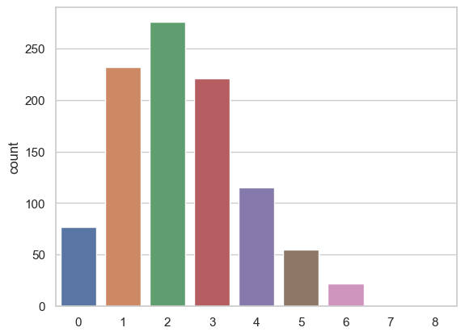

```python
two_rej = np.random.binomial(20, 0.12, 1000)
# import matplotlib.pyplot as plt
# import seaborn as sns
# np.random.seed(555)       # By using seed you can make sure that each time you get the same numbers
sns.set_theme(style="whitegrid")
sns.countplot(x=two_rej)
plt.show()
```

```python
from numpy import random

#generate an array of 10 values that follow a binomial distribution
random.binomial(n=10, p=.25, size=10)
```

```
array([5, 2, 4, 4, 3, 4, 4, 2, 2, 3])
```

**Question**: Aravind throws 60% of his balls in to a basket in his attempts. If he throws 12 balls at the basket, what is the probability that he exactly throws 10 balls into basket?

```python
from scipy.stats import binom

#calculate binomial probability
binom.pmf(k=10, n=12, p=0.6)
```

```
0.063852281856
```

**Question:** Manohar flips a fair coin 5 times. What is the probability that the coin lands on heads 2 times or fewer?

```python
from scipy.stats import binom

#calculate binomial probability
binom.cdf(k=2, n=5, p=0.5)
```

```
0.5
```

**Question:** In a company it is known that 70% of individuals want to create a new product. If 10 individuals are randomly selected, what is the probability that between 4 and 6 would want to create a new product in the company?

```python
from scipy.stats import binom
binom.pmf(k=5, n=10, p=0.7)
```

```
0.10291934519999998
```

```python
from scipy.stats import binom

#calculate binomial probability
binom.cdf(k=6, n=10, p=0.7) - binom.cdf(k=4, n=10, p=0.7)
```

[output not shown]

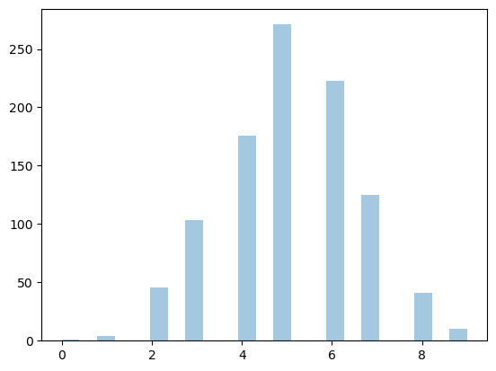

```python
from numpy import random
import matplotlib.pyplot as plt
import seaborn as sns

x = random.binomial(n=10, p=0.5, size=1000)

sns.distplot(x, hist=True, kde=False)

plt.show()

### The x-axis describes the number of successes during 10 trials and the y-axis
### displays the number of times each number of successes occurred during 1,000 experiments
```